# Run this Pluto Notebook | JuliaActuary

JuliaActuary

Practical, extensible, and open-source actuarial modeling and analysis.

```julia
begin
    using MortalityTables
    using Turing
    using UUIDs
    using DataFramesMeta
    using MCMCChains, Plots, StatsPlots
    using LinearAlgebra
    using PlutoUI; TableOfContents()
    using Pipe
    using StatisticalRethinking
    using StatsFuns
end
```

## Generating fake data

The problem of interest is to look at mortality rates, which are given in terms of exposures (whether or not a life experienced a death in a given year).

We'll grab some example rates from an insurance table, which has a "selection" component: When someone enters observation, say at age 50, their mortality is path dependent (so for someone who started being observed at 50 will have a different risk/mortality rate at age 55 than someone who started being observed at 45).

Addtionally, there may be additional groups of interest, such as:

- high/medium/low risk classification
- sex
- group (e.g. company, data source, etc.)
- type of insurance product offered

The example data will start with only the risk classification above

```julia
src = MortalityTables.table("2001 VBT Residual Standard Select and Ultimate - Male Nonsmoker, ANB")
```

```
MortalityTable (Insured Lives Mortality):
   Name:
       2001 VBT Residual Standard Select and Ultimate - Male Nonsmoker, ANB
   Fields:
       (:select, :ultimate, :metadata)
   Provider:
       Society of Actuaries
   mort.SOA.org ID:
       1118
   mort.SOA.org link:
       https://mort.soa.org/ViewTable.aspx?&TableIdentity=1118
   Description:
       2001 Valuation Basic Table (VBT) Residual Standard Select and Ultimate Table -  Male Nonsmoker. Basis: Age Nearest Birthday. Minimum Select Age: 0. Maximum Select Age: 99. Minimum Ultimate Age: 25. Maximum Ultimate Age: 120
```

```julia
src.select[50]
```

```
71-element OffsetArray(::Vector{Float64}, 50:120) with eltype Float64 with indices 50:120:
 0.00104
 0.00139
 0.00177
 0.00218
 0.00261
 0.00315
 0.00384
 ⋮
 0.75603
 0.79988
 0.84627
 0.89536
 0.94729
 1.0
```

```julia
n = 10_000
```

```
10000
```

```julia
function generate_data_individual(tbl,issue_age=rand(50:55),inforce_years=rand(1:30),risklevel=rand(1:3))
    # risk_factors will scale the "true" parameter up or down
    # we observe the assigned risklevel, but not risk_factor
    risk_factors = [0.7,1.0,1.5]
    rf = risk_factors[risklevel]
    deaths = rand(inforce_years) .< (tbl.select[issue_age][issue_age .+ inforce_years .- 1 ] .* rf)

    endpoint = if sum(deaths) == 0
        last(inforce_years)
    else
        findfirst(deaths)
    end
    id= uuid1()
    map(1:endpoint) do i
        (
        issue_age=issue_age,
        risklevel = risklevel,
        att_age = issue_age + i -1,
        death = deaths[i],
        id = id,
    )
    end

end
```

```
generate_data_individual (generic function with 4 methods)
```

```julia
exposures = vcat([generate_data_individual(src) for _ in 1:n]...) |> DataFrame
```

|  | issue_age | risklevel | att_age | death | id |
| --- | --- | --- | --- | --- | --- |
| 1 | 53 | 3 | 53 | false | UUID("972cab6c-93c9-11ed-0ddb-db5fd1b2311d") |
| 2 | 53 | 3 | 54 | false | UUID("972cab6c-93c9-11ed-0ddb-db5fd1b2311d") |
| 3 | 53 | 3 | 55 | false | UUID("972cab6c-93c9-11ed-0ddb-db5fd1b2311d") |
| 4 | 55 | 2 | 55 | false | UUID("9750238a-93c9-11ed-1fd3-eb3978daaa6b") |
| 5 | 55 | 2 | 56 | false | UUID("9750238a-93c9-11ed-1fd3-eb3978daaa6b") |
| 6 | 55 | 2 | 57 | false | UUID("9750238a-93c9-11ed-1fd3-eb3978daaa6b") |
| 7 | 55 | 2 | 58 | false | UUID("9750238a-93c9-11ed-1fd3-eb3978daaa6b") |
| 8 | 55 | 2 | 59 | false | UUID("9750238a-93c9-11ed-1fd3-eb3978daaa6b") |
| 9 | 55 | 2 | 60 | false | UUID("9750238a-93c9-11ed-1fd3-eb3978daaa6b") |
| 10 | 55 | 2 | 61 | false | UUID("9750238a-93c9-11ed-1fd3-eb3978daaa6b") |
| ... |  |  |  |  |  |
| 108849 | 52 | 3 | 53 | true | UUID("975c8ed6-93c9-11ed-1589-0dc00462a941") |

```julia
data = combine(groupby(exposures,[:issue_age,:att_age])) do subdf
    (exposures = nrow(subdf),
    deaths = sum(subdf.death),
    fraction = sum(subdf.death)/ nrow(subdf))
end
```

|  | issue_age | att_age | exposures | deaths | fraction |
| --- | --- | --- | --- | --- | --- |
| 1 | 50 | 50 | 1691 | 37 | 0.0218805 |
| 2 | 50 | 51 | 1592 | 22 | 0.0138191 |
| 3 | 50 | 52 | 1524 | 31 | 0.0203412 |
| 4 | 50 | 53 | 1419 | 28 | 0.0197322 |
| 5 | 50 | 54 | 1329 | 31 | 0.0233258 |
| 6 | 50 | 55 | 1244 | 18 | 0.0144695 |
| 7 | 50 | 56 | 1174 | 14 | 0.011925 |
| 8 | 50 | 57 | 1104 | 19 | 0.0172101 |
| 9 | 50 | 58 | 1032 | 25 | 0.0242248 |
| 10 | 50 | 59 | 967 | 31 | 0.0320579 |
| ... |  |  |  |  |  |
| 180 | 55 | 84 | 2 | 0 | 0.0 |

```julia
data2 = combine(groupby(exposures,[:issue_age,:att_age,:risklevel])) do subdf
    (exposures = nrow(subdf),
    deaths = sum(subdf.death),
    fraction = sum(subdf.death)/ nrow(subdf))
end
```

|  | issue_age | att_age | risklevel | exposures | deaths | fraction |
| --- | --- | --- | --- | --- | --- | --- |
| 1 | 50 | 50 | 1 | 575 | 5 | 0.00869565 |
| 2 | 50 | 50 | 2 | 560 | 11 | 0.0196429 |
| 3 | 50 | 50 | 3 | 556 | 21 | 0.0377698 |
| 4 | 50 | 51 | 1 | 548 | 7 | 0.0127737 |
| 5 | 50 | 51 | 2 | 533 | 7 | 0.0131332 |
| 6 | 50 | 51 | 3 | 511 | 8 | 0.0156556 |
| 7 | 50 | 52 | 1 | 522 | 7 | 0.01341 |
| 8 | 50 | 52 | 2 | 516 | 9 | 0.0174419 |
| 9 | 50 | 52 | 3 | 486 | 15 | 0.0308642 |
| 10 | 50 | 53 | 1 | 485 | 2 | 0.00412371 |
| ... |  |  |  |  |  |  |
| 531 | 55 | 84 | 1 | 2 | 0 | 0.0 |

## 1: A single binomial parameter model

Estiamte $p$, the average mortality rate, not accounting for any variation within the population/sample:

```julia
@model function mortality(data,deaths)
    p ~ Beta(1,1)
    for i = 1:nrow(data)
        deaths[i] ~ Binomial(data.exposures[i],p)
    end
end
```

```
mortality (generic function with 2 methods)
```

```julia
m1 = mortality(data,data.deaths)
```

```
DynamicPPL.Model{typeof(mortality), (:data, :deaths), (), (), Tuple{DataFrame, Vector{Int64}}, Tuple{}, DynamicPPL.DefaultContext}(Main.var"workspace#3".mortality, (data = 180×5 DataFrame
 Row │ issue_age  att_age  exposures  deaths  fraction
     │ Int64      Int64    Int64      Int64   Float64
─────┼──────────────────────────────────────────────────
   1 │        50       50       1691      37  0.0218805
   2 │        50       51       1592      22  0.0138191
   3 │        50       52       1524      31  0.0203412
   4 │        50       53       1419      28  0.0197322
   5 │        50       54       1329      31  0.0233258
  ⋮  │     ⋮         ⋮         ⋮        ⋮         ⋮
 177 │        55       81         25       1  0.04
 178 │        55       82         16       2  0.125
 179 │        55       83          8       0  0.0
 180 │        55       84          2       0  0.0
                                        171 rows omitted, deaths = [37, 22, 31, 28, 31, 18, 14, 19, 25, 31  …  7, 3, 6, 6, 5, 1, 1, 2, 0, 0]), NamedTuple(), DynamicPPL.DefaultContext())
```

```julia
num_chains = 4
```

```
4
```

### Sampling from the posterior

```julia
chain = sample(m1, NUTS(), 1000)
```

|  | iteration | chain | p | lp | n_steps | is_accept | acceptance_rate | log_density | ... |
| --- | --- | --- | --- | --- | --- | --- | --- | --- | --- |
| 1 | 501 | 1 | 0.0296173 | -565.871 | 1.0 | 1.0 | 1.0 | -565.871 |  |
| 2 | 502 | 1 | 0.028972 | -566.265 | 3.0 | 1.0 | 0.603777 | -566.265 |  |
| 3 | 503 | 1 | 0.028972 | -566.265 | 1.0 | 1.0 | 0.733405 | -566.265 |  |
| 4 | 504 | 1 | 0.0295351 | -565.833 | 3.0 | 1.0 | 0.595807 | -565.833 |  |
| 5 | 505 | 1 | 0.0291248 | -566.027 | 3.0 | 1.0 | 0.724427 | -566.027 |  |
| 6 | 506 | 1 | 0.0294442 | -565.82 | 3.0 | 1.0 | 0.644897 | -565.82 |  |
| 7 | 507 | 1 | 0.0293161 | -565.856 | 3.0 | 1.0 | 0.989477 | -565.856 |  |
| 8 | 508 | 1 | 0.0293161 | -565.856 | 1.0 | 1.0 | 0.94016 | -565.856 |  |
| 9 | 509 | 1 | 0.029315 | -565.856 | 3.0 | 1.0 | 0.699563 | -565.856 |  |
| 10 | 510 | 1 | 0.0303726 | -567.398 | 3.0 | 1.0 | 0.669545 | -567.398 |  |
| ... |  |  |  |  |  |  |  |  |  |

```julia
plot(chain)
```

[figure not shown]

### Plotting samples from the posterior

We can see that the sampling of possible posterior parameters doesn't really fit the data very well since our model was so simplified. The lines represent the posterior binomial probability.

This is saying that for the observed data, if there really is just a single probability `p` that governs the true process that came up with the data, there's a pretty narrow range of values it could possibly be:

```julia
let
    data_weight = data.exposures ./ sum(data.exposures)
    data_weight = .√(data_weight ./ maximum(data_weight) .* 20)

    p = scatter(
        data.att_age,
        data.fraction,
        markersize = data_weight,
        alpha = 0.5,
        label = "Experience data point (size indicates relative exposure quantity)",
        xlabel="age",
        ylim=(0.0,0.25),
        ylabel="mortality rate",
        title="Parametric Bayseian Mortality"
    )

    # show n samples from the posterior plotted on the graph
    n = 300
    ages = sort!(unique(data.att_age))

    for i in 1:n
        p_posterior = sample(chain,1)[:p][1]
        hline!([p_posterior],label="",alpha=0.1)
    end
    p

end
```

[figure not shown]

The posterior mean of `p` is of course very close to the simple proportoin of claims to exposures:

```julia
mean(chain,:p)
```

```
0.029440645004487405
```

```julia
sum(data.deaths) / sum(data.exposures)
```

```
0.029444459756175986
```

## 2. Parametric model

In this example, we utilize a MakehamBeard parameterization because it's already very similar in form to a [logistic function](https://en.wikipedia.org/wiki/Logistic_function). This is important because our desired output is a probability (ie the probablity of a death at a given age), so the value must be constrained to be in the interval between zero and one.

The **prior** values for `a`,`b`,`c`, and `k` are chosen to constrain the hazard (mortality) rate to be between zero and one.

This isn't an ideal parameterization (e.g. we aren't including information about the select underwriting period), but is an example of utilizing Bayesian techniques on life experience data.

```julia
@model function mortality2(data,deaths)
    a ~ Exponential(0.1)
    b ~ Exponential(0.1)
    c = 0.
    k ~ truncated(Exponential(1),1,Inf)

    # use the variables to create a parametric mortality model
    m = MortalityTables.MakehamBeard(;a,b,c,k)

    # loop through the rows of the dataframe to let Turing observe the data
    # and how consistent the parameters are with the data
    for i = 1:nrow(data)
        age = data.att_age[i]
        q = MortalityTables.hazard(m,age)
        deaths[i] ~ Binomial(data.exposures[i],q)
    end
end
```

```
mortality2 (generic function with 2 methods)
```

We combine the model with the data:

```julia
m2 = mortality2(data,data.deaths)
```

```
DynamicPPL.Model{typeof(mortality2), (:data, :deaths), (), (), Tuple{DataFrame, Vector{Int64}}, Tuple{}, DynamicPPL.DefaultContext}(Main.var"workspace#3".mortality2, (data = 180×5 DataFrame
 Row │ issue_age  att_age  exposures  deaths  fraction
     │ Int64      Int64    Int64      Int64   Float64
─────┼──────────────────────────────────────────────────
   1 │        50       50       1691      37  0.0218805
   2 │        50       51       1592      22  0.0138191
   3 │        50       52       1524      31  0.0203412
   4 │        50       53       1419      28  0.0197322
   5 │        50       54       1329      31  0.0233258
  ⋮  │     ⋮         ⋮         ⋮        ⋮         ⋮
 177 │        55       81         25       1  0.04
 178 │        55       82         16       2  0.125
 179 │        55       83          8       0  0.0
 180 │        55       84          2       0  0.0
                                        171 rows omitted, deaths = [37, 22, 31, 28, 31, 18, 14, 19, 25, 31  …  7, 3, 6, 6, 5, 1, 1, 2, 0, 0]), NamedTuple(), DynamicPPL.DefaultContext())
```

### Sampling from the posterior

We use a No-U-Turn-Sampler (NUTS) technique to sample:

```julia
chain2 = sample(m2, NUTS(), 1000)
```

|  | iteration | chain | a | b | k | lp | n_steps | is_accept | ... |
| --- | --- | --- | --- | --- | --- | --- | --- | --- | --- |
| 1 | 501 | 1 | 0.00538775 | 0.0285763 | 1.22514 | -508.349 | 47.0 | 1.0 |  |
| 2 | 502 | 1 | 0.00605425 | 0.0276171 | 2.11015 | -508.484 | 31.0 | 1.0 |  |
| 3 | 503 | 1 | 0.00424921 | 0.0327401 | 1.85763 | -507.655 | 31.0 | 1.0 |  |
| 4 | 504 | 1 | 0.00521705 | 0.0294948 | 1.83623 | -507.443 | 31.0 | 1.0 |  |
| 5 | 505 | 1 | 0.00429435 | 0.0322212 | 1.11689 | -508.758 | 63.0 | 1.0 |  |
| 6 | 506 | 1 | 0.00543553 | 0.0289158 | 1.14623 | -508.747 | 63.0 | 1.0 |  |
| 7 | 507 | 1 | 0.00550289 | 0.0293801 | 3.30914 | -508.596 | 63.0 | 1.0 |  |
| 8 | 508 | 1 | 0.00692691 | 0.0254078 | 2.18266 | -509.896 | 63.0 | 1.0 |  |
| 9 | 509 | 1 | 0.00393535 | 0.0336556 | 1.26862 | -508.705 | 31.0 | 1.0 |  |
| 10 | 510 | 1 | 0.00415108 | 0.0339217 | 1.71502 | -509.248 | 31.0 | 1.0 |  |
| ... |  |  |  |  |  |  |  |  |  |

```julia
summarize(chain2)
```

|  | parameters | mean | std | naive_se | mcse | ess | rhat | ess_per_sec |
| --- | --- | --- | --- | --- | --- | --- | --- | --- |
| 1 | :a | 0.00485458 | 0.000909626 | 2.87649e-5 | 4.57773e-5 | 319.526 | 1.00142 | 2.69408 |
| 2 | :b | 0.0311342 | 0.00304173 | 9.61878e-5 | 0.000141053 | 347.652 | 1.00007 | 2.93123 |
| 3 | :k | 1.85048 | 0.841972 | 0.0266255 | 0.0357123 | 467.084 | 0.999086 | 3.93821 |

```julia
plot(chain2)
```

[figure not shown]

### Plotting samples from the posterior

We can see that the sampling of possible posterior parameters fits the data well:

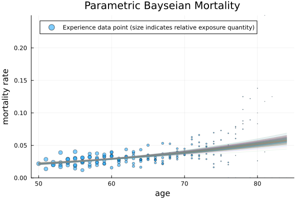

```julia
let
    data_weight = data.exposures ./ sum(data.exposures)
    data_weight = .√(data_weight ./ maximum(data_weight) .* 20)

    p = scatter(
        data.att_age,
        data.fraction,
        markersize = data_weight,
        alpha = 0.5,
        label = "Experience data point (size indicates relative exposure quantity)",
        xlabel="age",
        ylim=(0.0,0.25),
        ylabel="mortality rate",
        title="Parametric Bayseian Mortality"
    )


    # show n samples from the posterior plotted on the graph
    n = 300
    ages = sort!(unique(data.att_age))

    for i in 1:n
        s = sample(chain2,1)
        a = only(s[:a])
        b = only(s[:b])
        k = only(s[:k])
        c = 0
        m = MortalityTables.MakehamBeard(;a,b,c,k)
        plot!(ages,age -> MortalityTables.hazard(m,age), alpha = 0.1,label="")
    end
    p
end
```

## 3. Parametric model

This model extends the prior to create a multi-level model. Each risk class (`risklevel`) gets its own $a$ paramater in the `MakhamBeard` model. The prior for $a_i$ is determined by the hyperparameter $\bar{a}$.

```julia
@model function mortality3(data,deaths)
    risk_levels = length(levels(data.risklevel))
    b ~ Exponential(0.1)
    ā ~ Exponential(0.1)
    a ~ filldist(Exponential(ā), risk_levels)
    c = 0
    k ~ truncated(Exponential(1),1,Inf)

    # use the variables to create a parametric mortality model

    # loop through the rows of the dataframe to let Turing observe the data
    # and how consistent the parameters are with the data
    for i = 1:nrow(data)
        risk = data.risklevel[i]

        m = MortalityTables.MakehamBeard(;a=a[risk],b,c,k)
        age = data.att_age[i]
        q = MortalityTables.hazard(m,age)
        deaths[i] ~ Binomial(data.exposures[i],q)
    end
end
```

```
mortality3 (generic function with 2 methods)
```

```julia
m3 = mortality3(data2,data2.deaths)
```

```
DynamicPPL.Model{typeof(mortality3), (:data, :deaths), (), (), Tuple{DataFrame, Vector{Int64}}, Tuple{}, DynamicPPL.DefaultContext}(Main.var"workspace#3".mortality3, (data = 531×6 DataFrame
 Row │ issue_age  att_age  risklevel  exposures  deaths  fraction
     │ Int64      Int64    Int64      Int64      Int64   Float64
─────┼──────────────────────────────────────────────────────────────
   1 │        50       50          1        575       5  0.00869565
   2 │        50       50          2        560      11  0.0196429
   3 │        50       50          3        556      21  0.0377698
   4 │        50       51          1        548       7  0.0127737
   5 │        50       51          2        533       7  0.0131332
  ⋮  │     ⋮         ⋮         ⋮          ⋮        ⋮         ⋮
 528 │        55       83          1          5       0  0.0
 529 │        55       83          2          2       0  0.0
 530 │        55       83          3          1       0  0.0
 531 │        55       84          1          2       0  0.0
                                                    522 rows omitted, deaths = [5, 11, 21, 7, 7, 8, 7, 9, 15, 2  …  0, 1, 0, 1, 1, 0, 0, 0, 0, 0]), NamedTuple(), DynamicPPL.DefaultContext())
```

```julia
chain3 = sample(m3, NUTS(), 1000)
```

|  | iteration | chain | b | ā | a[1] | a[2] | a[3] | k | ... |
| --- | --- | --- | --- | --- | --- | --- | --- | --- | --- |
| 1 | 501 | 1 | 0.0397605 | 0.00747611 | 0.00204091 | 0.00282777 | 0.00456048 | 3.14971 |  |
| 2 | 502 | 1 | 0.0393775 | 0.00718988 | 0.0019361 | 0.00299858 | 0.00459479 | 2.67492 |  |
| 3 | 503 | 1 | 0.0382458 | 0.00455261 | 0.00205516 | 0.0030325 | 0.00465574 | 2.23378 |  |
| 4 | 504 | 1 | 0.0368445 | 0.00352418 | 0.00225198 | 0.00326397 | 0.00502476 | 1.52521 |  |
| 5 | 505 | 1 | 0.0341907 | 0.0147432 | 0.00260135 | 0.00393644 | 0.00590104 | 1.35102 |  |
| 6 | 506 | 1 | 0.0329568 | 0.017055 | 0.00279913 | 0.00416678 | 0.00639691 | 1.32034 |  |
| 7 | 507 | 1 | 0.0379495 | 0.00582986 | 0.00218864 | 0.00338655 | 0.00514394 | 3.43358 |  |
| 8 | 508 | 1 | 0.0337056 | 0.0123958 | 0.00265158 | 0.00399195 | 0.00588518 | 1.41406 |  |
| 9 | 509 | 1 | 0.0371748 | 0.00343053 | 0.00211543 | 0.00312111 | 0.00484137 | 1.00745 |  |
| 10 | 510 | 1 | 0.0345227 | 0.00464117 | 0.00253952 | 0.00372857 | 0.00578524 | 2.17735 |  |
| ... |  |  |  |  |  |  |  |  |  |

```julia
summarize(chain3)
```

|  | parameters | mean | std | naive_se | mcse | ess | rhat | ess_per_sec |
| --- | --- | --- | --- | --- | --- | --- | --- | --- |
| 1 | :b | 0.0376547 | 0.00372902 | 0.000117922 | 0.00019069 | 246.104 | 1.00899 | 0.749215 |
| 2 | :ā | 0.0087331 | 0.00974532 | 0.000308174 | 0.000501709 | 426.733 | 0.999014 | 1.29911 |
| 3 | Symbol("a[1]") | 0.00223165 | 0.000476801 | 1.50778e-5 | 2.48849e-5 | 260.92 | 1.01057 | 0.794322 |
| 4 | Symbol("a[2]") | 0.0032482 | 0.000670935 | 2.12168e-5 | 3.58145e-5 | 259.539 | 1.0101 | 0.790116 |
| 5 | Symbol("a[3]") | 0.00505183 | 0.00098926 | 3.12832e-5 | 5.27162e-5 | 263.255 | 1.01308 | 0.801429 |
| 6 | :k | 2.39737 | 1.32323 | 0.0418442 | 0.0563751 | 380.416 | 0.999039 | 1.1581 |

```julia
PRECIS(DataFrame(chain3))
```

```
┌───────┬───────────────────────────────────────────────────────┐
│ param │   mean     std    5.5%     50%   94.5%      histogram │
├───────┼───────────────────────────────────────────────────────┤
│  a[1] │ 0.0022  0.0005  0.0015  0.0022   0.003        ▁▆█▄▂▁▁ │
│  a[2] │ 0.0032  0.0007  0.0023  0.0032  0.0044      ▁▃██▆▃▁▁▁ │
│  a[3] │ 0.0051   0.001  0.0036   0.005  0.0068  ▁▂▄▇▇█▆▃▂▁▁▁▁ │
│     b │ 0.0377  0.0037  0.0321  0.0373  0.0436   ▁▁▂▄▇█▇▅▃▁▁▁ │
│     k │ 2.3974  1.3232  1.0745  1.9662  5.0622       █▄▂▂▁▁▁▁ │
│     ā │ 0.0087  0.0097  0.0022   0.006  0.0219       █▁▁▁▁▁▁▁ │
└───────┴───────────────────────────────────────────────────────┘
```

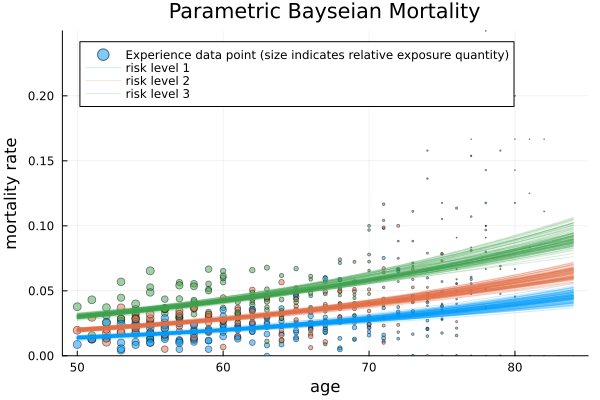

```julia
let data = data2

    data_weight = data.exposures ./ sum(data.exposures)
    data_weight = .√(data_weight ./ maximum(data_weight) .* 20)
    color_i = data.risklevel

    p = scatter(
        data.att_age,
        data.fraction,
        markersize = data_weight,
        alpha = 0.5,
        color=color_i,
        label = "Experience data point (size indicates relative exposure quantity)",
        xlabel="age",
        ylim=(0.0,0.25),
        ylabel="mortality rate",
        title="Parametric Bayseian Mortality"
    )


    # show n samples from the posterior plotted on the graph
    n = 100

    ages = sort!(unique(data.att_age))
    for r in 1:3
        for i in 1:n
            s = sample(chain3,1)
            a = only(s[Symbol("a[$r]")])
            b = only(s[:b])
            k = only(s[:k])
            c = 0
            m = MortalityTables.MakehamBeard(;a,b,c,k)
            if i == 1
                plot!(ages,age -> MortalityTables.hazard(m,age),label="risk level $r", alpha = 0.2,color=r)
            else
                plot!(ages,age -> MortalityTables.hazard(m,age),label="", alpha = 0.2,color=r)
            end
        end
    end
    p
end
```

## Handling non-unit exposures

The key is to use the Poisson distribution:

```julia
@model function mortality4(data,deaths)
    risk_levels = length(levels(data.risklevel))
    b ~ Exponential(0.1)
    ā ~ Exponential(0.1)
    a ~ filldist(Exponential(ā), risk_levels)
    c ~ Beta(4,18)
    k ~ truncated(Exponential(1),1,Inf)

    # use the variables to create a parametric mortality model

    # loop through the rows of the dataframe to let Turing observe the data
    # and how consistent the parameters are with the data
    for i = 1:nrow(data)
        risk = data.risklevel[i]

        m = MortalityTables.MakehamBeard(;a=a[risk],b,c,k)
        age = data.att_age[i]
        q = MortalityTables.hazard(m,age)
        deaths[i] ~ Poisson(data.exposures[i] * q)
    end
end
```

```
mortality4 (generic function with 2 methods)
```

```julia
m4 = mortality4(data2,data2.deaths)
```

```
DynamicPPL.Model{typeof(mortality4), (:data, :deaths), (), (), Tuple{DataFrame, Vector{Int64}}, Tuple{}, DynamicPPL.DefaultContext}(Main.var"workspace#3".mortality4, (data = 531×6 DataFrame
 Row │ issue_age  att_age  risklevel  exposures  deaths  fraction
     │ Int64      Int64    Int64      Int64      Int64   Float64
─────┼──────────────────────────────────────────────────────────────
   1 │        50       50          1        575       5  0.00869565
   2 │        50       50          2        560      11  0.0196429
   3 │        50       50          3        556      21  0.0377698
   4 │        50       51          1        548       7  0.0127737
   5 │        50       51          2        533       7  0.0131332
  ⋮  │     ⋮         ⋮         ⋮          ⋮        ⋮         ⋮
 528 │        55       83          1          5       0  0.0
 529 │        55       83          2          2       0  0.0
 530 │        55       83          3          1       0  0.0
 531 │        55       84          1          2       0  0.0
                                                    522 rows omitted, deaths = [5, 11, 21, 7, 7, 8, 7, 9, 15, 2  …  0, 1, 0, 1, 1, 0, 0, 0, 0, 0]), NamedTuple(), DynamicPPL.DefaultContext())
```

```julia
chain4 = sample(m4, NUTS(), 1000)
```

|  | iteration | chain | b | ā | a[1] | a[2] | a[3] | c | ... |
| --- | --- | --- | --- | --- | --- | --- | --- | --- | --- |
| 1 | 501 | 1 | 0.0439438 | 0.00307492 | 0.000870426 | 0.00149385 | 0.00255717 | 0.00638515 |  |
| 2 | 502 | 1 | 0.0438041 | 0.00591787 | 0.00108074 | 0.00160408 | 0.00290747 | 0.00694355 |  |
| 3 | 503 | 1 | 0.0417991 | 0.00359182 | 0.00126037 | 0.0021495 | 0.00330973 | 0.00474184 |  |
| 4 | 504 | 1 | 0.0416494 | 0.00268639 | 0.00130428 | 0.00197703 | 0.00325999 | 0.00528317 |  |
| 5 | 505 | 1 | 0.0508616 | 0.00126101 | 0.000628299 | 0.000956821 | 0.00164957 | 0.00809153 |  |
| 6 | 506 | 1 | 0.0524745 | 0.00151628 | 0.000407118 | 0.000850948 | 0.0014247 | 0.0098292 |  |
| 7 | 507 | 1 | 0.0440666 | 0.00198958 | 0.00104292 | 0.00186851 | 0.00317848 | 0.00531812 |  |
| 8 | 508 | 1 | 0.0493017 | 0.00451559 | 0.000665149 | 0.00118859 | 0.00186156 | 0.00715901 |  |
| 9 | 509 | 1 | 0.0483145 | 0.00784937 | 0.000785016 | 0.00139438 | 0.00221619 | 0.00743335 |  |
| 10 | 510 | 1 | 0.0488616 | 0.00382112 | 0.000843573 | 0.00124841 | 0.0024025 | 0.0048838 |  |
| ... |  |  |  |  |  |  |  |  |  |

```julia
PRECIS(DataFrame(chain4))
```

```
┌───────┬────────────────────────────────────────────────────────┐
│ param │   mean     std    5.5%     50%   94.5%       histogram │
├───────┼────────────────────────────────────────────────────────┤
│  a[1] │  0.001  0.0004  0.0004   0.001  0.0017  ▁▂▅█▇▇▆▄▂▁▁▁▁▁ │
│  a[2] │ 0.0016  0.0006  0.0007  0.0015  0.0026       ▁▅██▅▂▁▁▁ │
│  a[3] │ 0.0027  0.0009  0.0013  0.0026  0.0042   ▁▄▇██▇▅▂▁▁▁▁▁ │
│     b │ 0.0461  0.0058  0.0383  0.0453   0.056       ▁▃█▇▄▂▁▁▁ │
│     c │ 0.0061  0.0021  0.0026  0.0059  0.0096   ▁▃▄▆█▇▆▄▃▁▁▁▁ │
│     k │ 2.5842  1.4751  1.0752  2.1688  5.2745    █▅▃▂▁▁▁▁▁▁▁▁ │
│     ā │ 0.0052  0.0071  0.0008  0.0029   0.017        █▁▁▁▁▁▁▁ │
└───────┴────────────────────────────────────────────────────────┘
```

```julia
risk_factors4 = [mean(chain4[Symbol("a[$f]")]) for f in 1:3]
```

```
3-element Vector{Float64}:
 0.0009925896942950376
 0.001597560230398143
 0.0026938300706679545
```

```julia
risk_factors4 ./ risk_factors4[2]
```

```
3-element Vector{Float64}:
 0.6213159763295215
 1.0
 1.6862150292741074
```

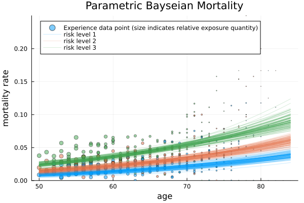

```julia
let data = data2

    data_weight = data.exposures ./ sum(data.exposures)
    data_weight = .√(data_weight ./ maximum(data_weight) .* 20)
    color_i = data.risklevel

    p = scatter(
        data.att_age,
        data.fraction,
        markersize = data_weight,
        alpha = 0.5,
        color=color_i,
        label = "Experience data point (size indicates relative exposure quantity)",
        xlabel="age",
        ylim=(0.0,0.25),
        ylabel="mortality rate",
        title="Parametric Bayseian Mortality"
    )


    # show n samples from the posterior plotted on the graph
    n = 100

    ages = sort!(unique(data.att_age))
    for r in 1:3
        for i in 1:n
            s = sample(chain4,1)
            a = only(s[Symbol("a[$r]")])
            b = only(s[:b])
            k = only(s[:k])
            c = 0
            m = MortalityTables.MakehamBeard(;a,b,c,k)
            if i == 1
                plot!(ages,age -> MortalityTables.hazard(m,age),label="risk level $r", alpha = 0.2,color=r)
            else
                plot!(ages,age -> MortalityTables.hazard(m,age),label="", alpha = 0.2,color=r)
            end
        end
    end
    p
end
```

## Predictions

We can generate predictive estimates by passing a vector of `missing` in place of the outcome variables and then calling `predict`.

We get a table of values where each row is the the prediction implied by the corresponding chain sample, and the columns are the predicted value for each of the outcomes in our original dataset.

```julia
preds = predict(mortality4(data2,fill(missing,length(data2.deaths))),chain4)
```

|  | iteration | chain | deaths[1] | deaths[2] | deaths[3] | deaths[4] | deaths[5] | deaths[6] | ... |
| --- | --- | --- | --- | --- | --- | --- | --- | --- | --- |
| 1 | 1 | 1 | 8.0 | 10.0 | 13.0 | 4.0 | 9.0 | 8.0 |  |
| 2 | 2 | 1 | 6.0 | 7.0 | 20.0 | 12.0 | 11.0 | 15.0 |  |
| 3 | 3 | 1 | 6.0 | 13.0 | 21.0 | 11.0 | 12.0 | 18.0 |  |
| 4 | 4 | 1 | 10.0 | 12.0 | 18.0 | 13.0 | 13.0 | 12.0 |  |
| 5 | 5 | 1 | 6.0 | 6.0 | 17.0 | 6.0 | 13.0 | 16.0 |  |
| 6 | 6 | 1 | 7.0 | 9.0 | 10.0 | 10.0 | 15.0 | 13.0 |  |
| 7 | 7 | 1 | 12.0 | 11.0 | 16.0 | 6.0 | 16.0 | 16.0 |  |
| 8 | 8 | 1 | 7.0 | 13.0 | 14.0 | 13.0 | 7.0 | 15.0 |  |
| 9 | 9 | 1 | 10.0 | 14.0 | 17.0 | 6.0 | 13.0 | 14.0 |  |
| 10 | 10 | 1 | 0.0 | 12.0 | 16.0 | 6.0 | 11.0 | 16.0 |  |
| ... |  |  |  |  |  |  |  |  |  |

```julia
size(preds)
```

```
(1000, 531, 1)
```

Built with Julia 1.8.5 and

DataFramesMeta 0.12.0  
MCMCChains 5.6.1  
MortalityTables 2.3.0  
Pipe 1.3.0  
Plots 1.36.6  
PlutoUI 0.7.49  
StatisticalRethinking 4.7.0  
StatsFuns 1.1.1  
StatsPlots 0.15.4  
Turing 0.23.3

## Run this Pluto Notebook

To run this page locally, download this file and open it with [Pluto.jl](https://plutojl.org).